# Step 2: Establishing a workflow for ATAC-seq-QC

Part B (step 2.2): ATAC-seq-data-analysis-QC with manual ln(1+x) normalization

Xenia Sirodzha

2025-02-10

Here, I aimed to establish a workflow for ATAC-Seq-QC by performing typical ATAC-seq-QC steps on a reduced set of data. All steps were approved by Alexander Sasse.

As the normalization options provided for Seurat’s `AggregateExpression` function are not sufficently normalizing the ATAC-seq data, in this step, the data was pseudo-bulked using Seurat’s `AggregateExpression` function and normalized manually afterwards. To assess the effects of this transformations the data was partially visualized. All plots were analogous to the ones in “02-06-ATAC-Seq-Analysis-Step-1.2.1 seurat norm”. Overall, the goal was to determine which normalization method to use ATAC-seq QC.

# Libraries

These are the packages required for the code below.

```r
library(tidyverse)
library(binom)
library(lubridate)
library(broom)
library(scales) #for scale transformations
```

```r
library(cowplot) #arranging plots
library(ggpubr)
library(ggridges)
library(ggthemes) #stylising plots
library(ggplot2)
library(ggsci)
library(wesanderson)
library(readxl) #for loading excel files
library(Seurat) #for rna-seq data, atac-seq data
library(Signac) #for atac seq data
```

# 1. Loading and inspecting

First, I loaded the sn-ATAC-seq Seurat Object, which contains the count matrix of 5 cell types and 1000 randomly selected peaks. More details about this Seurat Object can be found in “02-06-ATAC-Seq-Analysis-Step-1.1”.

```r
#load file

sub_zfish_atac <- readRDS("Data/sub_zfish_atac.rds")
glimpse(sub_zfish_atac)
```

```
## Formal class 'Seurat' [package "SeuratObject"] with 13 slots
##   ..@ assays      :List of 1
##   .. ..$ atac:Formal class 'Assay5' [package "SeuratObject"] with 8 slots
##   ..@ meta.data   :'data.frame': 5514 obs. of  27 variables:
##   .. ..$ orig.ident       : Factor w/ 6 levels "10hpf","12hpf",..: 5 5 5 5 5 5 5 5 5 5 ...
##   .. ..$ nCount_atac      : num [1:5514] 213 181 166 124 118 101 119 91 128 112 ...
##   .. ..$ nFeature_atac    : int [1:5514] 102 82 73 58 57 53 65 44 55 52 ...
##   .. ..$ ...1             : chr [1:5514] "5hpf_1#5.25hpf_1_BC0021_N02" "5hpf_1#5.25hpf_1_BC0012_N01" "5hpf_1#5.25hpf_1_BC0018_N01" "5hpf_1#5.25hpf_1_BC0078_N02" ...
##   .. ..$ Sample           : chr [1:5514] "5hpf_1" "5hpf_1" "5hpf_1" "5hpf_1" ...
##   .. ..$ TSSEnrichment    : num [1:5514] 8.7 10.07 9.01 8.62 8.5 ...
##   .. ..$ ReadsInTSS       : num [1:5514] 3175 3524 2745 2755 1652 ...
##   .. ..$ ReadsInPromoter  : num [1:5514] 14232 14938 11951 11721 7048 ...
##   .. ..$ ReadsInBlacklist : num [1:5514] 0 0 0 0 0 0 0 0 0 0 ...
##   .. ..$ PromoterRatio    : num [1:5514] 0.0787 0.0861 0.0835 0.0988 0.0615 ...
##   .. ..$ PassQC           : num [1:5514] 1 1 1 1 1 1 1 1 1 1 ...
##   .. ..$ NucleosomeRatio  : num [1:5514] 1.16 1.23 1.08 1.22 1.2 ...
##   .. ..$ nMultiFrags      : num [1:5514] 17542 13440 12844 11903 11281 ...
##   .. ..$ nMonoFrags       : num [1:5514] 41913 38847 34432 26658 26007 ...
##   .. ..$ nFrags           : num [1:5514] 90396 86794 71572 59314 57328 ...
##   .. ..$ nDiFrags         : num [1:5514] 30941 34507 24296 20753 20040 ...
##   .. ..$ BlacklistRatio   : num [1:5514] 0 0 0 0 0 0 0 0 0 0 ...
##   .. ..$ stage            : chr [1:5514] "5hpf" "5hpf" "5hpf" "5hpf" ...
##   .. ..$ Clusters         : chr [1:5514] "C1" "C1" "C1" "C1" ...
##   .. ..$ ReadsInPeaks     : num [1:5514] 78617 77133 68699 61051 46438 ...
##   .. ..$ FRIP             : num [1:5514] 0.435 0.444 0.48 0.515 0.405 ...
##   .. ..$ celltype         : chr [1:5514] "YSL/presumptive endoderm" "YSL/presumptive endoderm" "YSL/presumptive endoderm" "YSL/presumptive endoderm" ...
##   .. ..$ predictedCell    : chr [1:5514] "6h_3 CELL4337_N1 _" "6h_2_CELL3455_N1" "6h_2_CELL3657_N1" "LC-5.3h-2_CELL2003_N1_LC-5.3h-2" ...
##   .. ..$ predictedGroup   : chr [1:5514] "YSL/endoderm" "YSL/endoderm" "YSL/endoderm" "YSL/endoderm" ...
##   .. ..$ predictedScore   : num [1:5514] 0.919 0.949 0.806 0.631 0.92 ...
##   .. ..$ DoubletScore     : num [1:5514] 22.2 44.5 323.3 293.3 0 ...
##   .. ..$ DoubletEnrichment: num [1:5514] 3.3 4.4 51.5 12.4 0.3 1.4 2.1 0.2 24.1 11.6 ...
##   ..@ active.assay: chr "atac"
##   ..@ active.ident: Factor w/ 6 levels "10hpf","12hpf",..: 5 5 5 5 5 5 5 5 5 5 ...
##   .. ..- attr(*, "names")= chr [1:5514] "5hpf_1#5.25hpf_1_BC0021_N02" "5hpf_1#5.25hpf_1_BC0012_N01" "5hpf_1#5.25hpf_1_BC0018_N01" "5hpf_1#5.25hpf_1_BC0078_N02" ...
##   ..@ graphs      : list()
##   ..@ neighbors   : list()
##   ..@ reductions  : list()
##   ..@ images      : list()
##   ..@ project.name: chr "SeuratProject"
##   ..@ misc        : list()
##   ..@ version     :Classes 'package_version', 'numeric_version'  hidden list of 1
##   .. ..$ : int [1:3] 5 0 2
##   ..@ commands    : list()
##   ..@ tools       : list()
```

```r
# overview

sub_zfish_atac@assays$atac$counts[1:10,1:2]
```

```
## 10 x 2 sparse Matrix of class "dgCMatrix"
##                         5hpf_1#5.25hpf_1_BC0021_N02 5hpf_1#5.25hpf_1_BC0012_N01
## chr9:32899740-32900240                            .                           .
## chr3:23659616-23660116                            .                           .
## chr23:20345183-20345683                           .                           .
## chr10:42960480-42960980                           .                           .
## chr8:37188061-37188561                            .                           .
## chr13:17158940-17159440                           .                           .
## chr16:41378225-41378725                           .                           .
## chr3:51665105-51665605                            .                           .
## chr1:3336639-3337139                              .                           .
## chr5:31788585-31789085                            .                           .
```

Overall, this Seurat object contains both the count matrix and the meta data.

# 2. Data transformation

As pseudobulking using Seurat’s `AggregateExpression` function is functional (more details in “02-06-ATAC-Seq-Analysis-Step-1.2.1 seurat norm”), I used this function for this operation. Then, I normalized manually with a ln(1+x) transformation by using my own code. To ensure that all non determinant code is reproducible, I set a seed.

```r
## ensuring always the same random result
set.seed(59762489)

#testing if setting the seed worked
sample(1000,1) #running multiple times, same result
```

```
## [1] 684
```

## 2.1 Pseudo bulking and normalisation

To generate a matrix, which contains all un-normalized counts per cell type, I pseudo-bulked the count data from the `sub_zfish_atac` object by setting the arguments to: `return.seurat=F` and no specified normalization method, which is the default of this function.

```r
psd.bulk.sub_atc.lg1x= AggregateExpression(sub_zfish_atac, group.by = "celltype")
```

During ln(1+x) normalization, to calculate the average counts per 1000 cells before applying the ln transformation (`log` function in R) , all counts need to be divided by the number of cells in each celltype. To achieve this I performed the steps below.

First, I extracted the number of cells for each celltype.

```r
sub_zfish_atac@meta.data %>%
  group_by(celltype) %>%
  tally() %>% #extracts
  pivot_wider(names_from = celltype, values_from = n) %>%
  as.matrix() -> n_cells
n_cells
```

```
##      YSL/presumptive endoderm lateral plate mesoderm neural crest
## [1,]                      803                    944         1177
##      periderm/epidermis primary neuron
## [1,]                992           1598
```

Then, I tested whether dividing the counts by the number of cells within each cell type would work with the loop down below on a small scale.

```r
psd.bulk.sub_atc.lg1x$atac[1:5,1:5] -> test
test
```

```
## 5 x 5 sparse Matrix of class "dgCMatrix"
##                         lateral plate mesoderm neural crest periderm/epidermis
## chr9:32899740-32900240                       9           12                 24
## chr3:23659616-23660116                      29           27                 15
## chr23:20345183-20345683                      4           15                 11
## chr10:42960480-42960980                      6           34                 19
## chr8:37188061-37188561                     110          553                 22
##                         primary neuron YSL/presumptive endoderm
## chr9:32899740-32900240              16                       15
## chr3:23659616-23660116              16                       23
## chr23:20345183-20345683             10                       30
## chr10:42960480-42960980              5                       14
## chr8:37188061-37188561              13                       16
```

```r
## Loop through columns in n_cells
for (i in seq_along(colnames(n_cells))) {
  ct <- colnames(n_cells)[i]  # Extract column name from n_cells

  ## Loop through columns in test
  for (j in seq_along(colnames(psd.bulk.sub_atc.lg1x$atac[1:5,1:5]))) {
    atc <- colnames(test)[j]  # Extract column name

    ## If names match divide and store in test
    if (atc == ct) {
      test[,j] <- (test[, j] / n_cells[, i])*1000
      break  # stop if everything is matched
    }
  }
}

test
```

```
## 5 x 5 sparse Matrix of class "dgCMatrix"
##                         lateral plate mesoderm neural crest periderm/epidermis
## chr9:32899740-32900240                9.533898     10.19541           24.19355
## chr3:23659616-23660116               30.720339     22.93968           15.12097
## chr23:20345183-20345683               4.237288     12.74427           11.08871
## chr10:42960480-42960980               6.355932     28.88700           19.15323
## chr8:37188061-37188561              116.525424    469.83857           22.17742
##                         primary neuron YSL/presumptive endoderm
## chr9:32899740-32900240       10.012516                 18.67995
## chr3:23659616-23660116       10.012516                 28.64259
## chr23:20345183-20345683       6.257822                 37.35990
## chr10:42960480-42960980       3.128911                 17.43462
## chr8:37188061-37188561        8.135169                 19.92528
```

The loop was suitable for the operation. So i proceeded with the operations below.

```r
#Dividing the counts by the number of cells in each cell type

psd.bulk.sub_atc.lg1x$atac[1:5,1:5] #input
```

```
## 5 x 5 sparse Matrix of class "dgCMatrix"
##                         lateral plate mesoderm neural crest periderm/epidermis
## chr9:32899740-32900240                       9           12                 24
## chr3:23659616-23660116                      29           27                 15
## chr23:20345183-20345683                      4           15                 11
## chr10:42960480-42960980                      6           34                 19
## chr8:37188061-37188561                     110          553                 22
##                         primary neuron YSL/presumptive endoderm
## chr9:32899740-32900240              16                       15
## chr3:23659616-23660116              16                       23
## chr23:20345183-20345683             10                       30
## chr10:42960480-42960980              5                       14
## chr8:37188061-37188561              13                       16
```

```r
for (i in seq_along(colnames(n_cells))) {
  ct <- colnames(n_cells)[i]


  for (j in seq_along(colnames(psd.bulk.sub_atc.lg1x$atac))) {
    atc <- colnames(psd.bulk.sub_atc.lg1x$atac)[j]


    if (atc == ct) {
      psd.bulk.sub_atc.lg1x$atac[,j] <- (psd.bulk.sub_atc.lg1x$atac[, j] / n_cells[, i])*1000
      break  # stop if everything is matched
    }
  }
}

psd.bulk.sub_atc.lg1x$atac[1:5,1:5] #output
```

```
## 5 x 5 sparse Matrix of class "dgCMatrix"
##                         lateral plate mesoderm neural crest periderm/epidermis
## chr9:32899740-32900240                9.533898     10.19541           24.19355
## chr3:23659616-23660116               30.720339     22.93968           15.12097
## chr23:20345183-20345683               4.237288     12.74427           11.08871
## chr10:42960480-42960980               6.355932     28.88700           19.15323
## chr8:37188061-37188561              116.525424    469.83857           22.17742
##                         primary neuron YSL/presumptive endoderm
## chr9:32899740-32900240       10.012516                 18.67995
## chr3:23659616-23660116       10.012516                 28.64259
## chr23:20345183-20345683       6.257822                 37.35990
## chr10:42960480-42960980       3.128911                 17.43462
## chr8:37188061-37188561        8.135169                 19.92528
```

Then to log transform, I tested the operation on a small scale and proceeded afterwards.

```r
#Test what the operation does on a small scale

psd.bulk.sub_atc.lg1x$atac[1:3,1:5] #input
```

```
## 3 x 5 sparse Matrix of class "dgCMatrix"
##                         lateral plate mesoderm neural crest periderm/epidermis
## chr9:32899740-32900240                9.533898     10.19541           24.19355
## chr3:23659616-23660116               30.720339     22.93968           15.12097
## chr23:20345183-20345683               4.237288     12.74427           11.08871
##                         primary neuron YSL/presumptive endoderm
## chr9:32899740-32900240       10.012516                 18.67995
## chr3:23659616-23660116       10.012516                 28.64259
## chr23:20345183-20345683       6.257822                 37.35990
```

```r
log(psd.bulk.sub_atc.lg1x$atac[1:3,1:5]+1) #output
```

```
## 3 x 5 Matrix of class "dgeMatrix"
##                         lateral plate mesoderm neural crest periderm/epidermis
## chr9:32899740-32900240                2.354598     2.415504           3.226588
## chr3:23659616-23660116                3.456958     3.175537           2.780121
## chr23:20345183-20345683               1.655804     2.620622           2.492272
##                         primary neuron YSL/presumptive endoderm
## chr9:32899740-32900240        2.399032                 2.979600
## chr3:23659616-23660116        2.399032                 3.389212
## chr23:20345183-20345683       1.982080                 3.647013
```

I transformed the data in the manner shown below.

```r
psd.bulk.sub_atc.lg1x=log(psd.bulk.sub_atc.lg1x$atac+1)

psd.bulk.sub_atc.lg1x[1:10,1:5]
```

```
## 10 x 5 Matrix of class "dgeMatrix"
##                         lateral plate mesoderm neural crest periderm/epidermis
## chr9:32899740-32900240               2.3545985     2.415504           3.226588
## chr3:23659616-23660116               3.4569581     3.175537           2.780121
## chr23:20345183-20345683              1.6558038     2.620622           2.492272
## chr10:42960480-42960980              1.9955071     3.397424           3.003364
## chr8:37188061-37188561               4.7666547     6.154515           3.143179
## chr13:17158940-17159440              3.4229920     3.308283           2.086473
## chr16:41378225-41378725              1.6558038     1.266624           0.000000
## chr3:51665105-51665605               1.4298245     1.938357           2.492272
## chr1:3336639-3337139                 0.7223768     2.488652           2.204367
## chr5:31788585-31789085               3.4229920     3.175537           3.375052
##                         primary neuron YSL/presumptive endoderm
## chr9:32899740-32900240        2.399032                 2.979600
## chr3:23659616-23660116        2.399032                 3.389212
## chr23:20345183-20345683       1.982080                 3.647013
## chr10:42960480-42960980       1.418014                 2.914230
## chr8:37188061-37188561        2.212132                 3.040958
## chr13:17158940-17159440       2.812083                 2.914230
## chr16:41378225-41378725       1.891912                 1.977776
## chr3:51665105-51665605        1.682777                 3.469891
## chr1:3336639-3337139          1.792802                 2.502089
## chr5:31788585-31789085        2.556441                 1.555191
```

## 2.2 Data wrangling for plotting by celltype

After ln(1+x) normalization, I wrangled the data to be tidyverse ggplot compatible. First, I converted the matrix to a data frame, then I calculated the values which will be plotted as well(sum of pk_counts, coefficient of variance (cv)).

```r
as.data.frame(psd.bulk.sub_atc.lg1x)%>%
  pivot_longer(cols=!contains("rownames"), ,values_to = "pk_counts", names_to = "celltype") %>%
  mutate(pk_count_sum= sum(pk_counts)) %>%
  mutate(cv=sd(pk_counts) / mean(pk_counts)) %>%
  group_by(celltype) %>%
  mutate(pk_count_sum_celltype= sum(pk_counts)) %>%
  mutate(cv_celltype=sd(pk_counts) / mean(pk_counts)) %>%
  mutate(all="all celltypes")-> df_psd.bulk.sub_atc.lg1x

df_psd.bulk.sub_atc.lg1x
```

| celltype | pk_counts | pk_count_sum | cv | pk_count_sum_celltype | cv_celltype | all |
| --- | --- | --- | --- | --- | --- | --- |
| lateral plate mesoderm | 2.3545985 | 12770.74 | 0.4420735 | 2403.001 | 0.4705573 | all celltypes |
| neural crest | 2.4155041 | 12770.74 | 0.4420735 | 2465.078 | 0.4254937 | all celltypes |
| periderm/epidermis | 3.2265879 | 12770.74 | 0.4420735 | 2506.274 | 0.4427558 | all celltypes |
| primary neuron | 2.3990324 | 12770.74 | 0.4420735 | 2251.638 | 0.4504716 | all celltypes |
| YSL/presumptive endoderm | 2.9796004 | 12770.74 | 0.4420735 | 3144.745 | 0.3579217 | all celltypes |
| lateral plate mesoderm | 3.4569581 | 12770.74 | 0.4420735 | 2403.001 | 0.4705573 | all celltypes |
| neural crest | 3.1755372 | 12770.74 | 0.4420735 | 2465.078 | 0.4254937 | all celltypes |
| periderm/epidermis | 2.7801208 | 12770.74 | 0.4420735 | 2506.274 | 0.4427558 | all celltypes |
| primary neuron | 2.3990324 | 12770.74 | 0.4420735 | 2251.638 | 0.4504716 | all celltypes |
| YSL/presumptive endoderm | 3.3892122 | 12770.74 | 0.4420735 | 3144.745 | 0.3579217 | all celltypes |

[output cut: 4990 more lines]

# 3 Visualization

Overall, all data was plotted analogically to the visualization in “02-06-ATAC-Seq-Analysis-Step-1.2.1 seurat norm”.

## 3.1 Distribution after pseudo-bulking by celltype

Counts were plotted in a histogram overall and then by cell type.

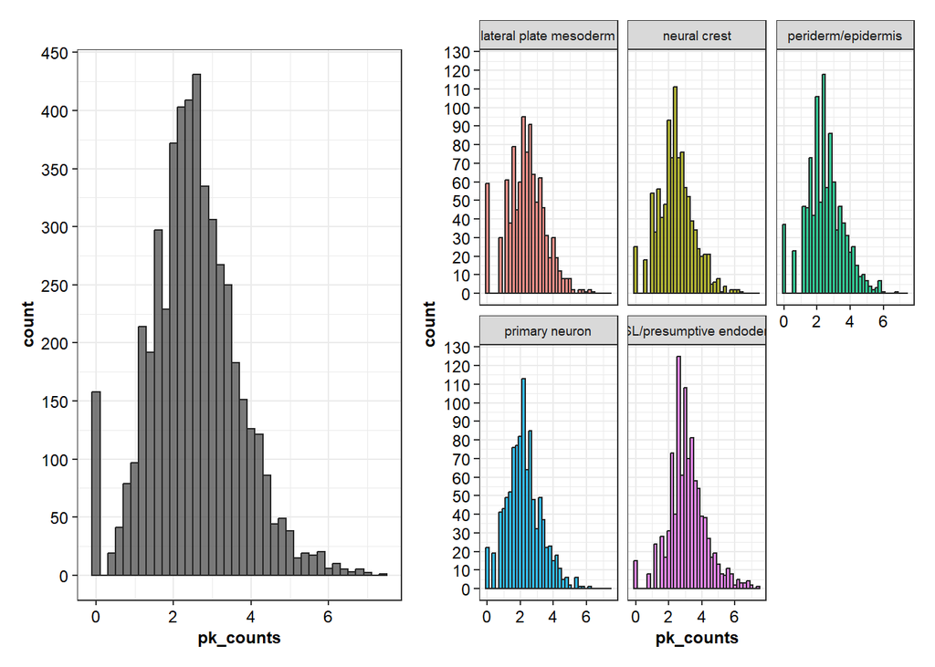

```r
# Overall

df_psd.bulk.sub_atc.lg1x %>%
 ggplot(aes(x=pk_counts))+geom_histogram(binwidth = 0.2, color="gray15", alpha=0.8)+
 scale_y_continuous(breaks = scales::breaks_pretty(n=10))+
  coord_fixed(ratio = 0.03)+
  theme_bw()+ theme(text = element_text(size = 9, family="sans", color="black"), #stylisation
        axis.text = element_text(size=9, color="black"),
        axis.title=element_text(size=9, face = "bold"),
        plot.subtitle=element_text(size=10.5),
        plot.title=element_text(size=11, face = "bold"),
        legend.position ="none") ->dis.counts.1


# by cell type

 ggplot(df_psd.bulk.sub_atc.lg1x, aes(x=pk_counts, fill = celltype))+
  geom_histogram(binwidth = 0.2, color="gray15", alpha=0.8)+
  scale_y_continuous(breaks = scales::breaks_pretty(n=10))+
  facet_wrap(facets = "celltype")+
  theme_bw()+ theme(text = element_text(size = 9, family="sans", color="black"), #stylisation
        axis.text = element_text(size=9, color="black"),
        axis.title=element_text(size=9, face = "bold"),
        plot.subtitle=element_text(size=10.5),
        plot.title=element_text(size=11, face = "bold"),
        legend.position ="none") ->dis.counts.cell.1

# display

dis.counts.1|dis.counts.cell.1
```

Generally, counts are somewhat normally distributed. There are no cell type specific trends. Most counts are between the values 1 and 5 which can be typical for well normalized ATAC-seq-data.

## 3.2 Sum of all peaks

I counted and visualized the sum of all peaks by cell type and in general.

In addition, I extracted the value for the sum of all peaks. It is 12770.74. Which is higher than with either Seurat provided normalization method (see 02-06-ATAC-Seq-Analysis-Step-1.2.1 seurat norm).

```r
unique(df_psd.bulk.sub_atc.lg1x$pk_count_sum)
```

```
## [1] 12770.74
```

The sums of all peaks were visualized in a barplot.

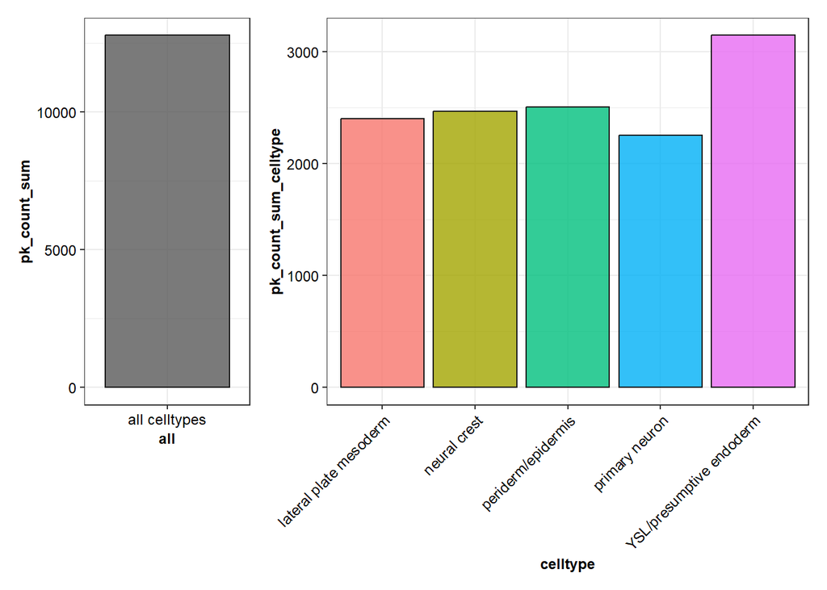

```r
# Overall

df_psd.bulk.sub_atc.lg1x %>%
  ungroup() %>%
  distinct(all, pk_count_sum) %>%
  ggplot(aes(x=all, y=pk_count_sum))+
  geom_col(alpha=0.8, color="gray10")+
  coord_fixed(ratio = 0.0002)+
  theme_bw()+ theme(text = element_text(size = 9, family="sans", color="black"), #stylisation
        axis.text = element_text(size=9, color="black"),
        axis.title=element_text(size=9, face = "bold"),
        plot.subtitle=element_text(size=10.5),
        plot.title=element_text(size=11, face = "bold"),
        legend.position ="none") -> sum.peaks.all.1


# by cell type

df_psd.bulk.sub_atc.lg1x %>%
  group_by(celltype) %>%
  distinct(pk_count_sum_celltype, pk_count_sum) %>%
  ggplot(aes(x=celltype, y=pk_count_sum_celltype, fill=celltype))+
  geom_col(alpha=0.8, color="gray10")+
  theme_bw()+ theme(text = element_text(size = 9, family="sans", color="black"), #stylisation
        axis.text = element_text(size=9, color="black"),
        axis.title=element_text(size=9, face = "bold"),
        axis.text.x = element_text(angle = 45, hjust = 1),
        plot.subtitle=element_text(size=10.5),
        plot.title=element_text(size=11, face = "bold"),
        legend.position ="none") -> sum.peaks.celltype.1

sum.peaks.all.1|sum.peaks.celltype.1
```

Apart from the YSL/presumptive endoderm cells with a little over 3000 peak count sum, all cells have a similar peak count sum. Overall, the proportion of the sum of all peaks is similar to previous normalization methods.

## 3.3 Coefficient of variation

The coefficient of variation was visualized as the sum of all peaks previously.

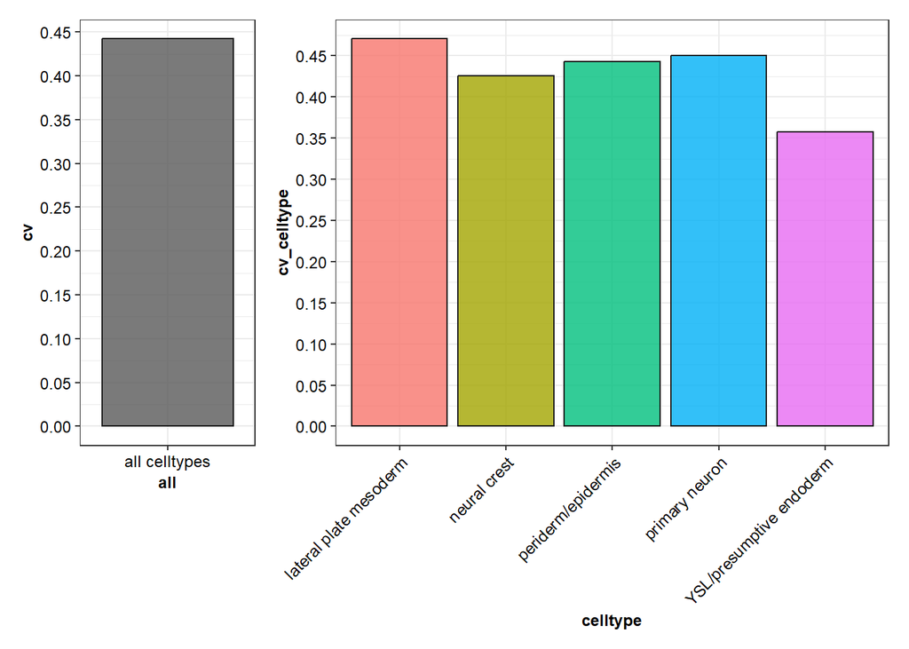

```r
# Overall

df_psd.bulk.sub_atc.lg1x %>%
  ungroup() %>%
  distinct(all, cv) %>%
  ggplot(aes(x=all, y=cv ))+
  geom_col(alpha=0.8, color="gray10")+
  scale_y_continuous(n.breaks=10)+
  coord_fixed(ratio = 6)+
  theme_bw()+ theme(text = element_text(size = 9, family="sans", color="black"), #stylisation
        axis.text = element_text(size=9, color="black"),
        axis.title=element_text(size=9, face = "bold"),
        plot.subtitle=element_text(size=10.5),
        plot.title=element_text(size=11, face = "bold"),
        legend.position ="none") -> cv.all.1


# by cell type

df_psd.bulk.sub_atc.lg1x %>%
  group_by(celltype) %>%
  distinct(cv_celltype, cv) %>%
  ggplot(aes(x=celltype, y=cv_celltype, fill=celltype))+
  geom_col(alpha=0.8, color="gray10")+
  scale_y_continuous(n.breaks=10)+
  theme_bw()+ theme(text = element_text(size = 9, family="sans", color="black"), #stylisation
        axis.text = element_text(size=9, color="black"),
        axis.title=element_text(size=9, face = "bold"),
        axis.text.x = element_text(angle = 45, hjust = 1),
        plot.subtitle=element_text(size=10.5),
        plot.title=element_text(size=11, face = "bold"),
        legend.position ="none") ->cv.celltype.1

cv.all.1|cv.celltype.1
```

Overall, coefficients of variation of each cell type are very similar to one another and to the coefficient of variation of all cells. However, YSL/presumptive endoderm cells have the lowest coefficient of variation.

## 3.4 Count distribution by cell type

Then, just as previously count distribution was visualized with a violin plot.

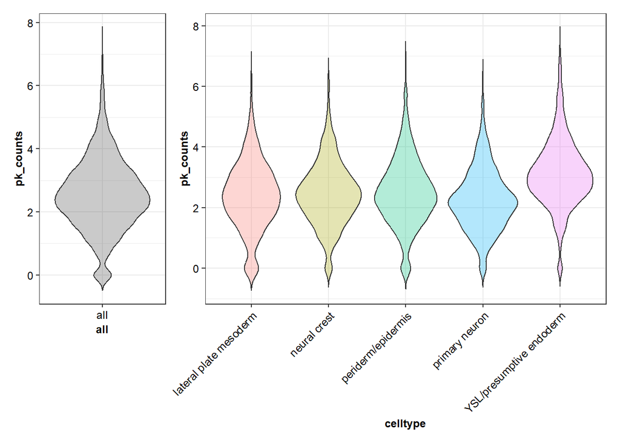

```r
df_psd.bulk.sub_atc.lg1x %>%
  mutate(all="all") %>%
 ggplot( aes( x=all, y=pk_counts))+
  geom_violin(color="grey20", alpha=0.3, fill="gray30", trim=F)+
  coord_fixed(ratio = 0.3)+
  theme_bw()+ theme(text = element_text(size = 9, family="sans", color="black"), #stylisation
        axis.text = element_text(size=9, color="black"),
        axis.title=element_text(size=9, face = "bold"),
        plot.subtitle=element_text(size=10.5),
        plot.title=element_text(size=11, face = "bold"),
        legend.position ="none") -> v.plot.all.1


 ggplot(df_psd.bulk.sub_atc.lg1x, aes(x=celltype, y=pk_counts, fill = celltype))+
  geom_violin(color="grey20", alpha=0.3, trim=F)+
  theme_bw()+ theme(text = element_text(size = 9, family="sans", color="black"), #stylisation
        axis.text = element_text(size=9, color="black"),
        axis.text.x = element_text(angle = 45, hjust = 1),
        axis.title=element_text(size=9, face = "bold"),
        plot.subtitle=element_text(size=10.5),
        plot.title=element_text(size=11, face = "bold"),
        legend.position ="none") -> v.plot.cells.1

 v.plot.all.1|v.plot.cells.1
```

To visualize median and quantiles, a boxplot was added.

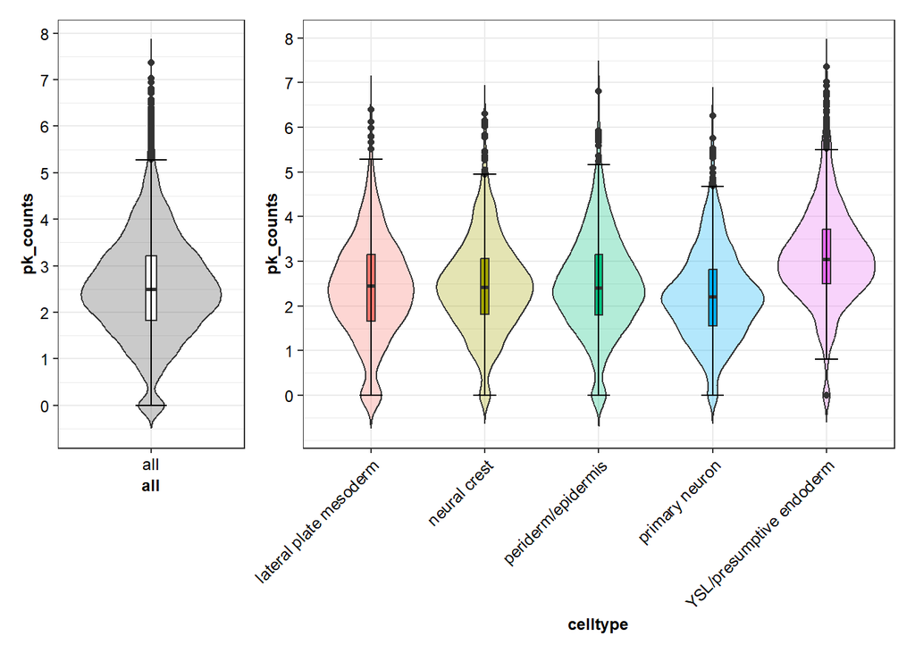

```r
df_psd.bulk.sub_atc.lg1x %>%
  mutate(all="all") %>%
 ggplot( aes( x=all, y=pk_counts))+
  geom_violin(color="grey20", alpha=0.3, fill="gray30", trim=F)+
  geom_boxplot(width = 0.07)+
  stat_boxplot(geom ='errorbar', width=0.2, position=position_dodge(0.5))+
  scale_y_continuous(breaks = seq(0,10,1))+ #y-axis more easily readable
  coord_fixed(ratio = 0.3)+
  theme_bw()+ theme(text = element_text(size = 9, family="sans", color="black"), #stylisation
        axis.text = element_text(size=9, color="black"),
        axis.title=element_text(size=9, face = "bold"),
        plot.subtitle=element_text(size=10.5),
        plot.title=element_text(size=11, face = "bold"),
        legend.position ="none") -> v.plot.all.box.1


 ggplot(df_psd.bulk.sub_atc.lg1x, aes(x=celltype, y=pk_counts, fill = celltype))+
  geom_violin(color="grey20", alpha=0.3, trim=F)+
  geom_boxplot(width = 0.07)+
  stat_boxplot(geom ='errorbar', width=0.2, position=position_dodge(0.5))+
    scale_y_continuous(breaks = seq(0,10,1))+ #y-axis more easily readable
  theme_bw()+ theme(text = element_text(size = 9, family="sans", color="black"), #stylisation
        axis.text = element_text(size=9, color="black"),
        axis.text.x = element_text(angle = 45, hjust = 1),
        axis.title=element_text(size=9, face = "bold"),
        plot.subtitle=element_text(size=10.5),
        plot.title=element_text(size=11, face = "bold"),
        legend.position ="none") -> v.plot.cells.box.1

 v.plot.all.box.1|v.plot.cells.box.1
```

The counts are similarly distributed, however values are more centered around count value 2.5. Most counts have values ranging from 0.5 to 4. In addition, YSL/presumptive endoderm cells have higher counts than all other cell types. In contrast to the normalized data in “02-06-ATAC-Seq-Analysis-Step-1.2.1 seurat norm”, most counts range from 0.5 to 5, which is similar to what one would expect in well-normalized ATAC-seq data.

# 4. Summary

Overall, manual ln(1+x) normalization after pseudo-bulking, leads to normally distributed counts with a wider range than in with Seurat’s `AggregateExpression` function normalized data. In addition, the values are centered around a higher value 2.5. Therefore, it is likely that this the normalization method I should use when I perform ATAC-seq QC. Nonetheless, both log based normalization methods were applied to the entire data set after pseudobulking.